# Attrition, Mediation

## Attrition

Random assignment permits causal inference because we can treat the **observed** Y(1) and Y(0) as unbiased samples of the full schedule of potential outcomes, and thereby estimated the ATE.

Attrition occurs when outcome data are missing.

Note that attrition can occur for several reasons:

- data get lost, or other administrative errors
- people don’t take your post-treatment survey for some reason
- after random assignment, you exclude some participants for some reason (e.g. dropping “outliers”)

When attrition is systematically related to potential outcomes, the remaining subects assigned to T or C no longer constitute random samples of the original collection of subjects, and therefore the ATE could be biased.

### A Working Example with Potential Outcomes

In this example, missingness itself is a potential outcome *R*:

- R(1) denotes whether the outcome is observed when the subject is assigned to the treatment group (Z=1)
- R(0) denotes whether the outcome is observed when Z=0

Notice that whether a subject’s outcome is reported may differ depending on the experiment group to which the subject was assigned.

| Hypothetical Schedule of Potential Outcomes with Attrition | Hypothetical Schedule of Potential Outcomes with Attrition Y(0) | Hypothetical Schedule of Potential Outcomes with Attrition Y(1) | Hypothetical Schedule of Potential Outcomes with Attrition r(0) | Hypothetical Schedule of Potential Outcomes with Attrition r(1) | Hypothetical Schedule of Potential Outcomes with Attrition Y(0)\|r(0) | Hypothetical Schedule of Potential Outcomes with Attrition Y(1)\|r(1) |
| --- | --- | --- | --- | --- | --- | --- |
| A | 3 | 8 | 0 | 1 | na | 8 |
| B | 3 | 7 | 0 | 1 | na | 7 |
| C | 8 | 10 | 1 | 1 | 8 | 10 |
| D | 7 | 8 | 1 | 1 | 7 | 8 |
| E | 6 | 6 | 0 | 0 | na | na |
| F | 5 | 8 | 1 | 1 | 5 | 8 |
| G | 6 | 6 | 1 | 0 | 6 | na |
| H | 6 | 7 | 1 | 1 | 6 | 7 |

In the above example:

- Subject E is always missing
- Subjects A and B are only missing is assigned to the control group
- Subject G is only missing if assigned to the treatment group

**Questions:**

1. What is the “true” ATE?
2. What is the ATE if we only compare the average values of the non-missing potential outcomes?

Notice that (2) is what we would obtain on average if we ran a large number of experiments and randomly assigned subjects to treatment and control groups and calculated the ATE, ignoring missing observations.

Here, the bias results because missingness is correlated with potential outcomes. In particular, lower values of Y are missing, and more subjects are missing when assigned to C rather than when assigned to T.

For instance, the fact that subjects A and B (low Y) are never observed in the control group inflates the average Y(0), which reduces the ATE below the “true” value.

More generally, the expected value of Y(0) is a weighted average of control outcomes amongst (i) those who are observable, and (ii) those with missing data.

The same holds for Y(1) wrt treatment outcomes.

But this yields an interesting implication: what happens when (i) = (ii) for both Y(0) and Y(1)?

### Missing Independent of Potential Outcomes (MIPO)

The key issue is whether subjects with missing outcomes have, on average, the same expected potential outcomes as subjects for whom outcome data are available.

If so, comparing Y(1) and Y(0) can still yield unbiased inferences, although attrition reduces the effective sample size and thus increases standard errors.

Here, we could compare missing vs non-missing people on pre-treatment characteristics (assuming these are available). This would yield some indirect evidence of MIPO.

In practice, you could regress R on prognostic covariates and experimental assignment. The resulting F-test should be non-significant.

**But be careful:** failure to reject the null is not the same as proving MIPO. For instance:

- Your covariates may not be very predictive of potential outcomes
- Your sample size may be insufficiently large

In addition to statistical tests, you should also use your understanding of how and why missingness occurs to assess whether this assumption is a reasonable approximation.

### MIPO | X

Sometimes, it could be the case that missingness is higher for some subgroups (X), but MIPO holds within subgroups:

| Hypothetical Schedule of Potential Outcomes with Attrition and Subgroups | Hypothetical Schedule of Potential Outcomes with Attrition and Subgroups Y(0) | Hypothetical Schedule of Potential Outcomes with Attrition and Subgroups Y(1) | Hypothetical Schedule of Potential Outcomes with Attrition and Subgroups r(0) | Hypothetical Schedule of Potential Outcomes with Attrition and Subgroups r(1) | Hypothetical Schedule of Potential Outcomes with Attrition and Subgroups Y(0)\|r(0) | Hypothetical Schedule of Potential Outcomes with Attrition and Subgroups Y(1)\|r(1) | Hypothetical Schedule of Potential Outcomes with Attrition and Subgroups X |
| --- | --- | --- | --- | --- | --- | --- | --- |
| A | 3 | 4 | 1 | 1 | 3 | 4 | 1 |
| B | 4 | 7 | 1 | 1 | 4 | 7 | 1 |
| C | 3 | 4 | 1 | 1 | 3 | 4 | 1 |
| D | 4 | 7 | 1 | 1 | 4 | 7 | 1 |
| E | 10 | 14 | 0 | 0 | na | na | 2 |
| F | 12 | 18 | 0 | 0 | na | na | 2 |
| G | 10 | 14 | 1 | 1 | 10 | 14 | 2 |
| H | 12 | 18 | 1 | 1 | 12 | 18 | 2 |

Questions:

1. What is the “true” ATE?
2. What is the ATE given missing data?
3. What is the ATE for X=1?
4. What is the ATE for X=2?

Notice that half of X=2 is missing (and attrition is MIPO). To recover the group size of X=2, weight each observation in this subgroup by 2.

5. What is the reweighted ATE given missing data?

**But be careful:** if the assumption of MIPO | X is incorrect, then applying weights will make the bias worse.

And in any case: weighting may increase the sampling variability of the estimates, because extra weight is placed on subsamples with a large share of missing observations.

### Placing Bounds on the ATE

Both MIPO and MIPO | X rely upon strong assumptions that are often not directly observable.

Instead, you may want to place some bounds on the treatment effect by estimating the largest and smallest ATEs that would obtain if the missing information were filled in with extremely high or low outcomes.

This approach, although cautious, as the advantage that it comes with few assumptions.

To illustrate, suppose that the missing outcomes below range theoretically from 0 to 10:

| Hypothetical Schedule of Potential Outcomes with Attrition | Hypothetical Schedule of Potential Outcomes with Attrition Y(0) | Hypothetical Schedule of Potential Outcomes with Attrition Y(1) | Hypothetical Schedule of Potential Outcomes with Attrition r(0) | Hypothetical Schedule of Potential Outcomes with Attrition r(1) | Hypothetical Schedule of Potential Outcomes with Attrition Y(0)\|r(0) | Hypothetical Schedule of Potential Outcomes with Attrition Y(1)\|r(1) |
| --- | --- | --- | --- | --- | --- | --- |
| A | 3 | 8 | 0 | 1 | na | 8 |
| B | 3 | 7 | 0 | 1 | na | 7 |
| C | 8 | 10 | 1 | 1 | 8 | 10 |
| D | 7 | 8 | 1 | 1 | 7 | 8 |
| E | 6 | 6 | 0 | 0 | na | na |
| F | 5 | 8 | 1 | 1 | 5 | 8 |
| G | 6 | 6 | 1 | 0 | 6 | na |
| H | 6 | 7 | 1 | 1 | 6 | 7 |

Suppose further that, in your experiment:

- the control group contains **A**, **D**, **F** and **H**
- the treatment group contains **B**, **C**, **E**, and **G**

To find the upper bound:

1. For those assigned to T, fill in missing values with 10
2. For those assigned to C, fill in missing values with 0
3. Calculate the ATE

To find the lower bound: 1. For those assigned to T, fill in missing values with 0 1. For those assigned to C, fill in missing values with 10 1. Calculate the ATE

What do you notice?

- The bounds contain the true ATE
- The bounds are wide

Bounds tend to be more useful when:

- only a small number of observations are missing
- the range of outcome variables is small (e.g. dichotomous dummy variables)

## Mediation

**A motivating example:** suppose PharmaCo develops a new drug to lower blood pressure. However, it is found that the drug also causes headaches, which prompts patients to also take aspirin (which also lowers blood pressure).

One question we might ask: how much of the difference in blood pressure between T and C is due to the direct effects of the drug, and how much is due to the indirect effects of the increased aspirin usage?

In this example, aspirin mediates at least some of the total difference between T and C.

**Another example:** in the 18th century, it was found that eating limes could reduce the incidence of scurvy amongst the sailors in the British navy. The key ingredient in limes is vitamin C. In this case, the mediator vitamin C explains completely the link between limes and scurvy.

### Regression pitfalls

Scholars commonly use regression to examine the effects of mediators. The typical approach estimates two equations:

$$Y = \alpha_1 + \beta Z +
\epsilon_1$$
$$Y = \alpha_2 + \beta Z
+ \delta M + \epsilon_2$$
The change in $\beta$ is then taken as an indicator of how much of the direct effect is mediated through M.

The problem is that M is not randomly assigned. In our example, we can randomly assign who gets the blood pressure drug. We cannot randomly assign how much aspirin patients take.

Including M in the model turns our experiment into an observational study, and brings the threat of ommited variable bias back in.

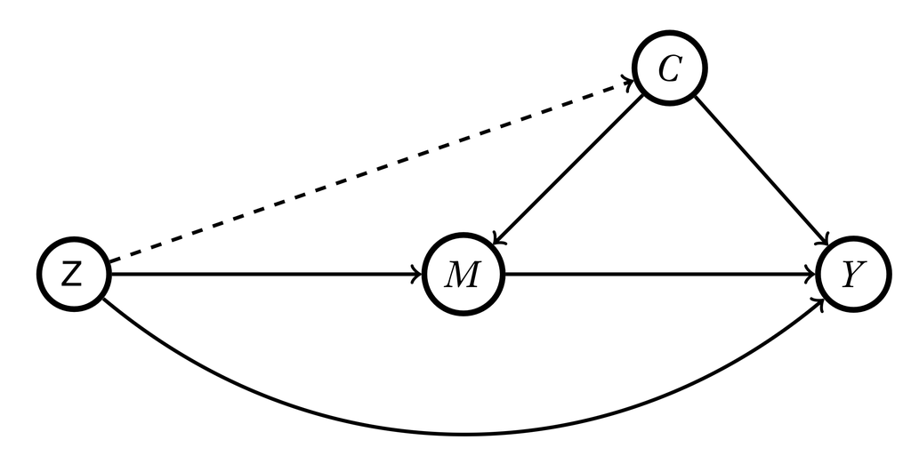

Suppose C represents the (unobserved) tendency to develop headaches. This is likely correlated with both aspirin intake (M) and blood pressure (Y).

Without modeling this, both $\beta$ and $\delta$ will be biased.

In fact, the “standard” regression approach only works if:

1. The model includes all relevant C variables to block the backdoor paths from M to Y, and
2. C must be unrelated to Z

### A Sobering Toy Example

Download a toy example [**here.**](https://nanzhangresearch.github.io/mediation_example.do)

This example is based on the following data, where Y is solely a function of Z (and M, by design, plays no role):

| Example of potential outcomes for Y and M assuming no effect of M on Y | Example of potential outcomes for Y and M assuming no effect of M on Y popshare | Example of potential outcomes for Y and M assuming no effect of M on Y M(1) | Example of potential outcomes for Y and M assuming no effect of M on Y M(0) | Example of potential outcomes for Y and M assuming no effect of M on Y Y(1) | Example of potential outcomes for Y and M assuming no effect of M on Y Y(0) | Example of potential outcomes for Y and M assuming no effect of M on Y Z | Example of potential outcomes for Y and M assuming no effect of M on Y M | Example of potential outcomes for Y and M assuming no effect of M on Y Y |
| --- | --- | --- | --- | --- | --- | --- | --- | --- |
| A | 1/6 | 1 | 1 | 1 | 0 | 0 | 1 | 0 |
| B | 1/6 | 1 | 1 | 1 | 0 | 1 | 1 | 1 |
| C | 1/6 | 3 | 0 | 3 | 2 | 0 | 0 | 2 |
| D | 1/6 | 3 | 0 | 3 | 2 | 1 | 3 | 3 |
| E | 1/6 | 2 | 2 | 5 | 4 | 0 | 2 | 4 |
| F | 1/6 | 2 | 2 | 5 | 4 | 1 | 2 | 5 |

Questions:

1. Regress Y on Z. What is the ATE?
2. Regress Y on Z and M. What does your regression tell you?

In general, the regression approach will overestimate $\delta$ and underestimate $\beta$, making your mediator look more “successful” than it actually is.

### Why Mediation is Hard

When you estimate the equation:

$$Y = \alpha_2 + \beta Z + \delta M +
\epsilon_2$$

You are asking two questions:

1. (Indirect causal path): How would Y change if we were to hold Z constant while varying M by the amount it would change if Z were varied?
2. (Direct causal path): How would Y change if we were to vary Z while holding M constant at the value it would take on for a given value of Z?

Translated into our limes example:

3. What would be the effect of increasing vitamin C intake on scurvy rates, holding lime consumption constant.
4. What would be the effect of increasing lime consumption on scurvy rates, holding vitamin C intake constant?

**What treatments would you design to answer these questions?**

Note that in many real world applications (not involving medicine), it is not so easy to simultaneously manipulate both Z and M (think about your own experiments)!

### What can we do?

While it is difficult to causally disentangle indirect and direct effects on Y, we can easily estimate the effect of treatment assignment on the mediator:

$$M = \alpha_3 + \zeta Z +
\epsilon_3$$
We can therefore rule out the influence of a subset of mediators.

Consider the following field experiment. A random set of local football clubs across Norway were sent the following email:

**Subject:** Football for everyone - for inclusion and against racism

*Dear coach,*

*Football is the world’s most popular sport and it gives us responsibility and the opportunity to unite people from different backgrounds. It is important for all of us that football is multicultural and diverse and reflects our entire society - not just for professionals, but for all players. At the amateur level, football facilitates integration and promotes interaction on and off the field. We aim to make football easily accessible to all members of our society.*

*Racism and exclusion are a societal problem and, thus, also a problem of football.*

*Scientific studies showed that it is more difficult for people with foreign names to join an amateur football club. Regardless of sport or language skills, players with foreign names are less likely to get a response when contacting a club for the first time.*

*This barrier to participating in sports is not only negative for foreigners, but also for Norwegians with a migration background and the Norwegian society. Creating diverse teams with members from different backgrounds is the key to improving social inclusion.*

*We have sent this email to encourage everyon to continue to keep the door to football open to all interested.*

The field experiment further conducted an audit study where interested players with “foreign” vs. Norwegian names contacted coaches and ask to be invited to a training.

The DV measures discrimination in terms of who was invited.

Notice that the treatment email could manipulate two quantities of interest:

1. An appeal to increase diversity
2. A statement that discrimination exists in football

Here, M = belief that other coaches discriminate.

The authors hoped that the email would reduce discrimination rates. In what direction would M influence the total treatment effect of the email on discrimination?

What would you do to test whether M is actually affected by Z?

Notice that you could have also redsigned this experiment with 3 versions of the email:

1. appeal to increase diversity + statement that discrimination is a problem in football
2. appeal to increase diversity without statement
3. statement that discrimination is a problem in football without appeal

Comparing the three treatments would allow us to shed light on the influence of M

## Main Takeaways

1. The potential outcomes framework provides the basis for making causal inferences about the effects of treatments.
2. This framework also underlies the logic of hypothesis testing (using randomization inference) under the sharp null hypothesis
3. Field experiments rely on relatively few assumptions – namely, only the exclusion restriction and non-interference, but these are important!
4. Despite their simplicity and transparency, there are myriad issues relating to blocking, covariates, subgroup analyses, compliance, attrition, ethics, etc. that need to be considered in the design stage.
5. The best way to solidify your understanding of these issues is to run an experiment yourself!

Please take a moment to fill in this (anonymous) [feedback questionnaire](https://makingdiversitywork.qualtrics.com/jfe/form/SV_eaNUmj6dzEusxv0).